# Some tests of credibility models

Giorgio A. Spedicato, Ph.D FCAS FSA CSPA, Christophe Dutang, Ph.D, Quentin Guibert, Ph.D

juin 04, 2021

# 1 Dataset formatting for `cm()`

## 1.1 Load dataset

```r
if(dir.exists("~/drop2/Dropbox/CAS PROJECT 2020 CREDIBILITY/data/grouped"))
{
  odir <- getwd()
  setwd("~/drop2/Dropbox/CAS PROJECT 2020 CREDIBILITY/data/grouped")
} else{
  odir <- getwd()
  setwd("C:/Users/qguib/Dropbox/CAS PROJECT 2020 CREDIBILITY/data/grouped")
}

cpn.unbal <- read.csv("cpn_anonymized_data_grped_unbal.csv", stringsAsFactors=TRUE, colClasses = "numeric")

cpnmkt.unbal <- read.csv("cpnmkt_anonymized_data_grped_unbal.csv", stringsAsFactors=TRUE,
                         colClasses = c("factor", rep("numeric", 55)))

head(cpn.unbal)
```

```
##   zone_id Expo1998 Expo1999 Expo2000 Expo2001 Expo2002 Expo2003 Expo2004
## 1      16       NA       NA       NA       NA       NA       NA       NA
## 2      23       NA       NA       NA       NA       NA       NA       NA
## 3      32       NA       NA       NA       NA       NA       NA       NA
## 4      49       NA       NA       NA       NA       NA       NA       NA
## 5      93       NA       NA       NA       NA       NA       NA       NA
## 6      94       NA       NA       NA       NA       NA       NA       NA
##   Expo2005 Expo2006 Expo2007 Expo2008 Claims1998 Claims1999 Claims2000
## 1       NA       NA       NA     2134         NA         NA         NA
## 2       NA       NA       NA     2950         NA         NA         NA
## 3       NA       NA       NA     6740         NA         NA         NA
## 4       NA       NA       NA     5620         NA         NA         NA
## 5       NA       NA       NA      200         NA         NA         NA
## 6       NA       NA       NA     1560         NA         NA         NA
##   Claims2001 Claims2002 Claims2003 Claims2004 Claims2005 Claims2006 Claims2007
```

[output cut: 34 more lines]

```r
if(dir.exists("~/drop2/Dropbox/CAS PROJECT 2020 CREDIBILITY/data/"))
{
  setwd(odir)
}
```

## 1.2 Description (reminder)

The following variables are contained in the provided data set:

- *exposure*: the insurance exposure measures by classification group, on which the rate is filled (aggregated outcomes);
- *claims*: the number of claims by classification group (aggregated outcomes);
- *ID*: unique row number (helper variable);
- *zone_id*: territory (aggregating variable);
- *year*: filing year (aggregating variable);
- *group*: random partition of the dataset into train, valid and test set.
- *cat1*: categorical variable 1, available in the original file (aggregating variable);
- *cat2*: categorical variable 2, available in the original file (aggregating variable);
- *cat3*: categorical variable 3, available in the original file (aggregating variable);
- *cat4-cat8*: categorical variables related to the territory (joined to the original file by zone_id);
- *cont1-cont12*: numeric variables related to the territory (joined to the original file by zone_id);

Categorical and continuous covariates have been anonymized by label encoding and scaling (calibrated on market data). In addition, the last available year (2008) has been used as test set, while data from precedent years have been randomly split between train and validation sets on a 80/20 basis.

# 2 Basic buhlmann Straub model per dataset

## 2.1 Basic buhlmann Straub model of claim number or claim relative frequency – company only

Compute simple buhlmann Straub model of claim number or claim relative frequency per zone_id on the company dataset

```r
library(actuar)
cpn.buhlstraub.nb <- cm(~ cat1+ cat1:cat2+ cat1:cat2:zone_id, ratios=Claims2003:Claims2008,
                        weights=Expo2003:Expo2008, data=cpn.unbal)
cpn.buhlstraub.freq <- cm(~ cat1+ cat1:cat2+ cat1:cat2:zone_id, ratios=Freq2003:Freq2008,
                          weights=Expo2003:Expo2008, data=cpn.unbal)
```

Using the claim number (absolute value) or the claim frequency (relative number) leads to complete different results

```r
my.summary.cm(summary(cpn.buhlstraub.nb))
```

```
## Call:
## cm(formula = ~cat1 + cat1:cat2 + cat1:cat2:zone_id, data = cpn.unbal,
##     ratios = Claims2003:Claims2008, weights = Expo2003:Expo2008)
##
## Structure Parameters Estimators
##
##   Collective premium: 320.6825
##
##   Between cat1 variance: 0
##   Within cat1/Between cat2 variance: 814218.7
##   Within cat2/Between zone_id variance: 56660515
##   Within zone_id variance: 547828094033
##
## Detailed premiums
##
##   Level: cat1
##     cat1 Indiv. mean  Weight       Cred. factor Cred. premium
##     0    3.357434e+00 4.517846e-01 0            320.6825
##     1    0.000000e+00 2.401173e-03 0            320.6825
##     2    0.000000e+00 4.427388e-02 0            320.6825
##  ...
##     cat1 Indiv. mean  Weight       Cred. factor Cred. premium
##     278  3.843848e+02 3.334270e-01 0            320.6825
##     279  7.282128e+01 1.945180e-02 0            320.6825
##     280  1.694396e+02 5.479443e-02 0            320.6825
##
##   Level: cat2
##     cat1 cat2 Indiv. mean  Weight       Cred. factor Cred. premium
##     0    1    7.755537e+00 1.691938e+01 1.955812e-01  259.47983
##     0    2    0.000000e+00 5.024851e+00 6.734491e-02  299.08613
##     0    3    0.000000e+00 3.424743e+00 4.690557e-02  305.64066
##  ...
##     cat1 cat2 Indiv. mean  Weight       Cred. factor Cred. premium
##     279  9    5.777872e-01 2.223286e-01 3.184715e-03  319.66302
##     280  4    0.000000e+00 1.008224e-02 1.448621e-04  320.63600
##     280  6    1.698887e+02 4.022846e+00 5.464957e-02  312.44164
##
##   Level: zone_id
##     cat1 cat2 zone_id Indiv. mean  Weight  Cred. factor Cred. premium
##     0    1    16      0.000000e+00    2134 0.1808075536 2.125639e+02
##     0    1    23      0.000000e+00    2950 0.2337817989 1.988182e+02
##     0    1    32      0.000000e+00    6740 0.4107601049 1.528959e+02
##  ...
##     cat1 cat2 zone_id Indiv. mean  Weight  Cred. factor Cred. premium
##     279  9    4733    0.000000e+00     300 0.0300944839 2.698358e+02
##     280  4    2779    0.000000e+00       4 0.0004135391 3.205479e+02
##     280  6    2779    0.000000e+00       4 0.0004135391 3.205479e+02
```

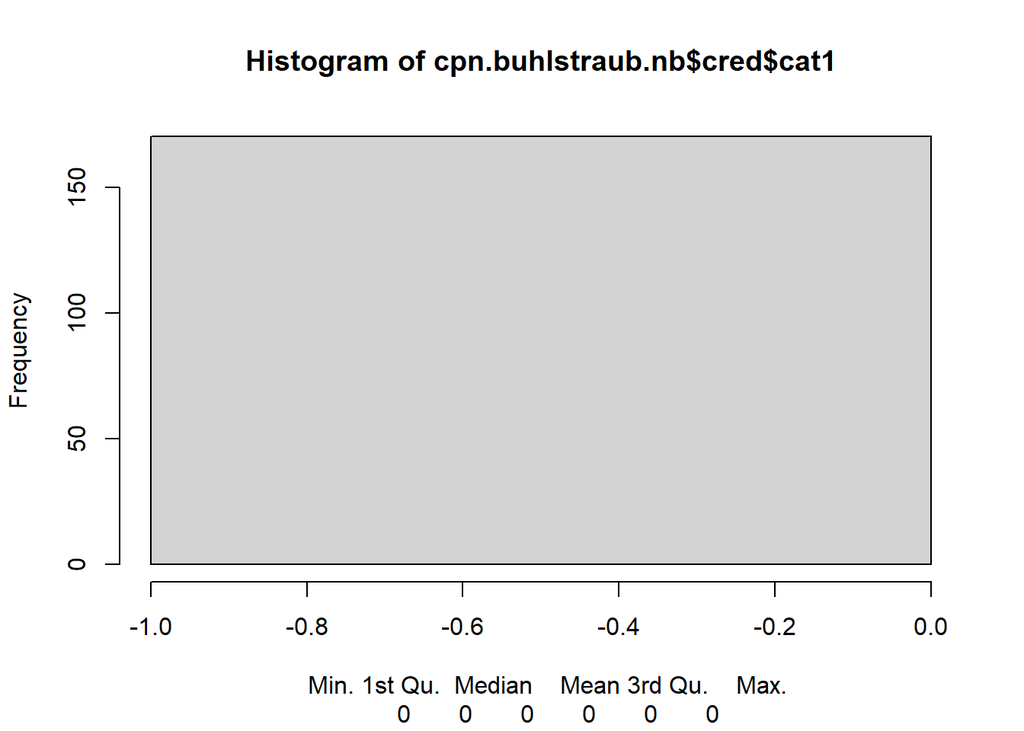

```r
hist(cpn.buhlstraub.nb$cred$cat1, xlab=capture.output(summary(cpn.buhlstraub.nb$cred$cat1)))
```

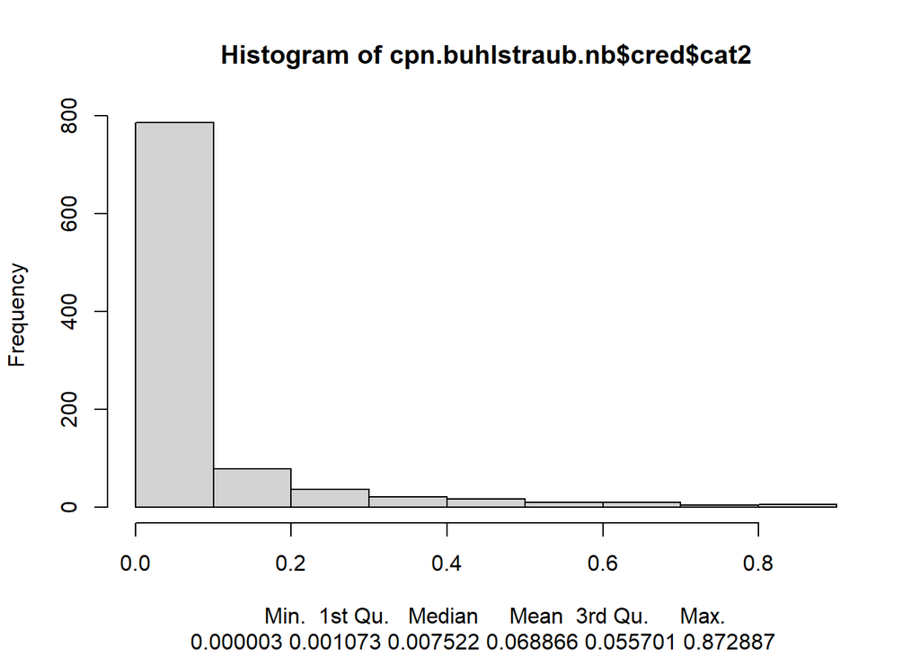

```r
hist(cpn.buhlstraub.nb$cred$cat2, xlab=capture.output(summary(cpn.buhlstraub.nb$cred$cat2)))
```

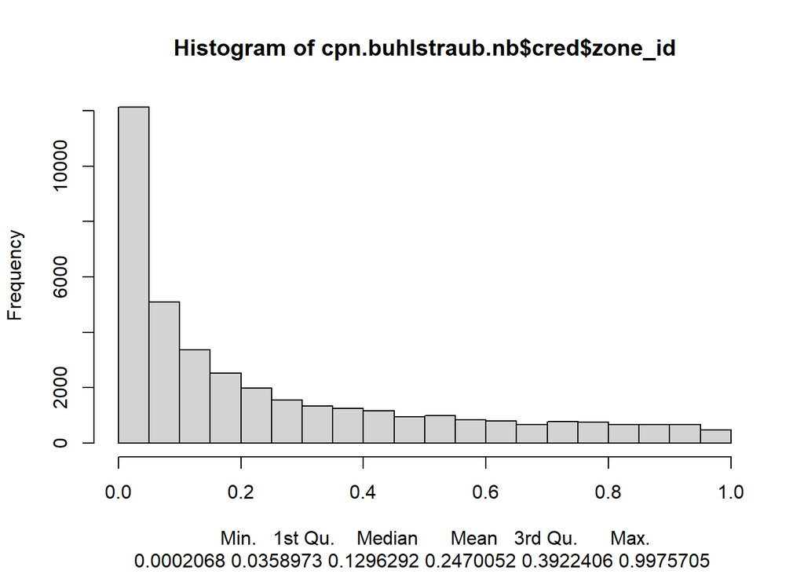

```r
hist(cpn.buhlstraub.nb$cred$zone_id, xlab=capture.output(summary(cpn.buhlstraub.nb$cred$zone_id)))
```

```r
my.summary.cm(summary(cpn.buhlstraub.freq))
```

```
## Call:
## cm(formula = ~cat1 + cat1:cat2 + cat1:cat2:zone_id, data = cpn.unbal,
##     ratios = Freq2003:Freq2008, weights = Expo2003:Expo2008)
##
## Structure Parameters Estimators
##
##   Collective premium: 0.01149326
##
##   Between cat1 variance: 0.0001487124
##   Within cat1/Between cat2 variance: 0.0002254608
##   Within cat2/Between zone_id variance: 0.0002391451
##   Within zone_id variance: 12.27621
##
## Detailed premiums
##
##   Level: cat1
##     cat1 Indiv. mean  Weight       Cred. factor Cred. premium
##     0    1.641939e-04 3.2265369433 0.6803274986 0.003785785
##     1    0.000000e+00 0.0297468542 0.0192432514 0.011272093
##     2    0.000000e+00 0.5953873049 0.2819771606 0.008252424
##  ...
##     cat1 Indiv. mean  Weight       Cred. factor Cred. premium
##     278  2.474871e-02 1.6185330779 0.5163411987 0.018337593
##     279  3.350988e-02 0.2718246784 0.1520348027 0.014840553
##     280  6.154680e-02 0.4711420796 0.2370850311 0.023360206
##
##   Level: cat2
##     cat1 cat2 Indiv. mean  Weight       Cred. factor Cred. premium
##     0    1    6.392345e-04 5.133836e+00 8.287692e-01 1.178021e-03
##     0    2    0.000000e+00 1.324597e+00 5.553187e-01 1.683468e-03
##     0    3    0.000000e+00 8.025905e-01 4.307395e-01 2.155098e-03
##  ...
##     cat1 cat2 Indiv. mean  Weight       Cred. factor Cred. premium
##     279  9    3.799482e-03 4.601848e-02 4.158122e-02 1.438145e-02
##     280  4    0.000000e+00 1.907163e-03 1.794805e-03 2.331828e-02
##     280  6    6.178216e-02 9.381542e-01 4.693473e-01 4.139344e-02
##
##   Level: zone_id
##     cat1 cat2 zone_id Indiv. mean  Weight  Cred. factor Cred. premium
##     0    1    16      0.000000e+00    2134 3.991190e-02 1.131004e-03
##     0    1    23      0.000000e+00    2950 5.434406e-02 1.114002e-03
##     0    1    32      0.000000e+00    6740 1.160593e-01 1.041301e-03
##  ...
##     cat1 cat2 zone_id Indiv. mean  Weight  Cred. factor Cred. premium
##     279  9    4733    0.000000e+00     300 5.810152e-03 2.883308e-03
##     280  4    2779    0.000000e+00       4 7.791536e-05 6.619782e-03
##     280  6    2779    0.000000e+00       4 7.791536e-05 9.483137e-03
```

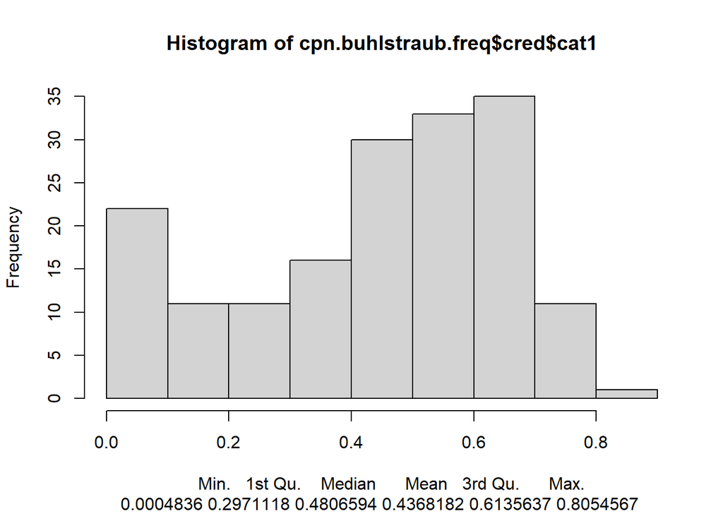

```r
hist(cpn.buhlstraub.freq$cred$cat1, xlab=capture.output(summary(cpn.buhlstraub.freq$cred$cat1)))
```

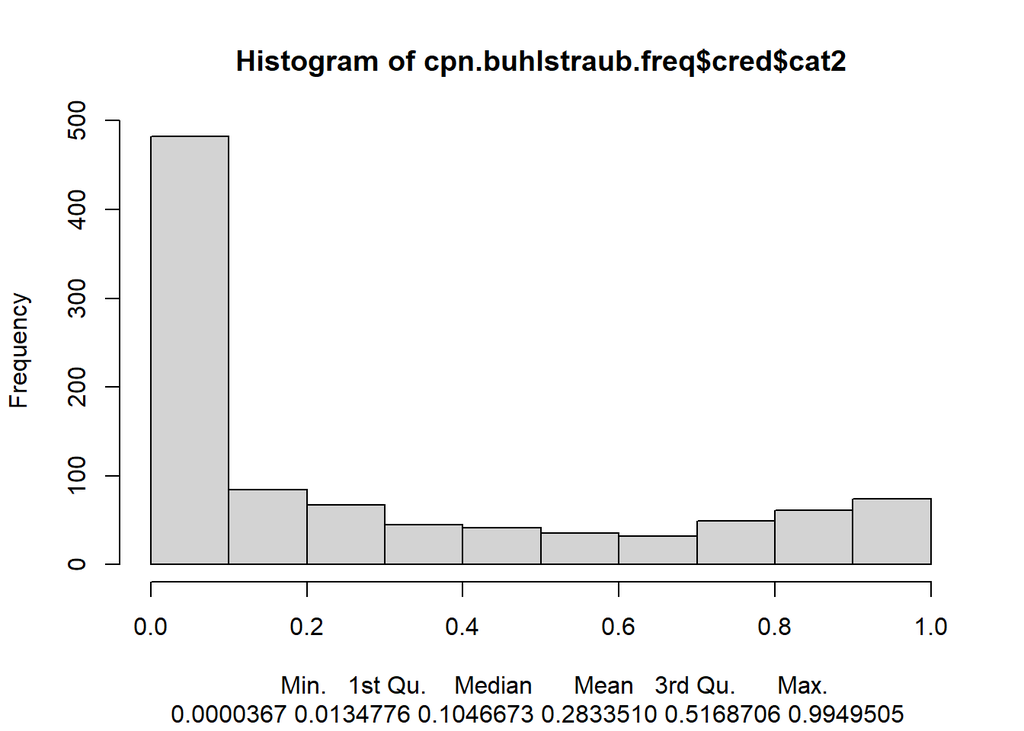

```r
hist(cpn.buhlstraub.freq$cred$cat2, xlab=capture.output(summary(cpn.buhlstraub.freq$cred$cat2)))
```

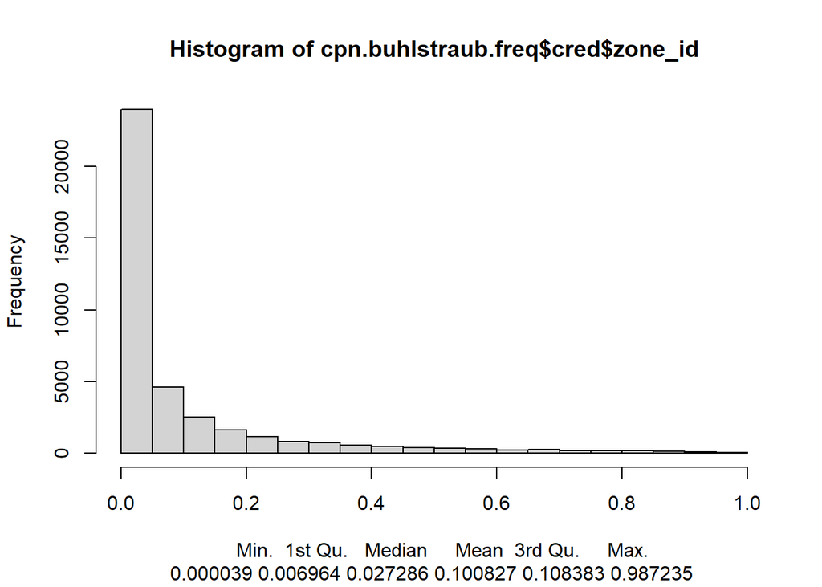

```r
hist(cpn.buhlstraub.freq$cred$zone_id, xlab=capture.output(summary(cpn.buhlstraub.freq$cred$zone_id)))
```

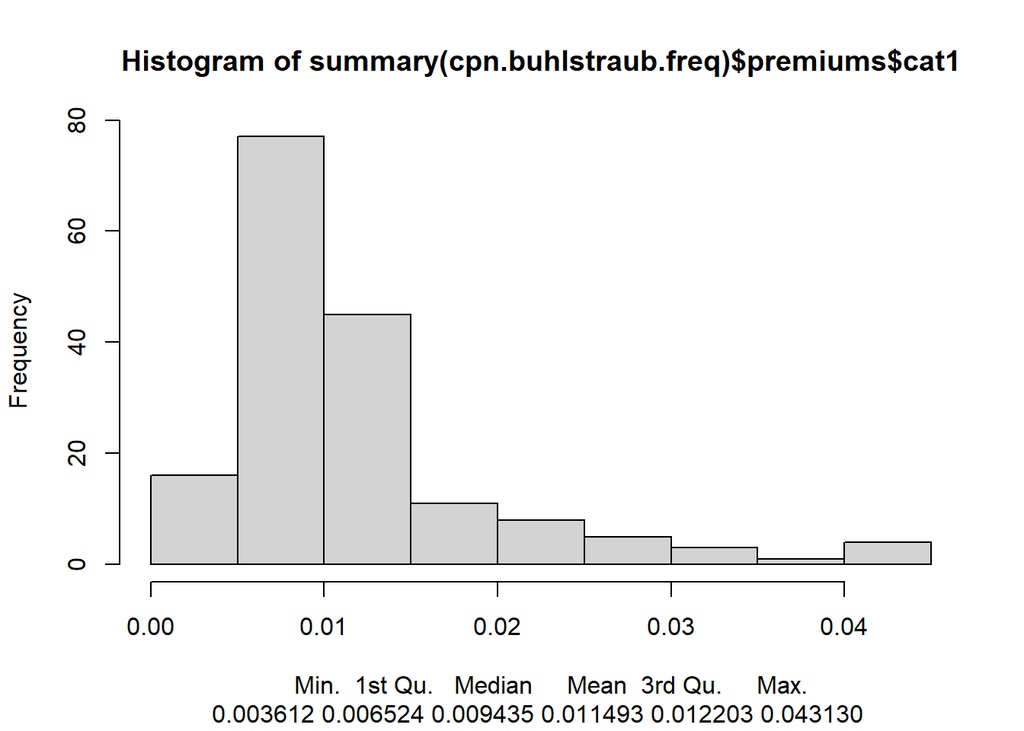

```r
hist(summary(cpn.buhlstraub.freq)$premiums$cat1, xlab=capture.output(summary(summary(cpn.buhlstraub.freq)$premiums$cat1)))
```

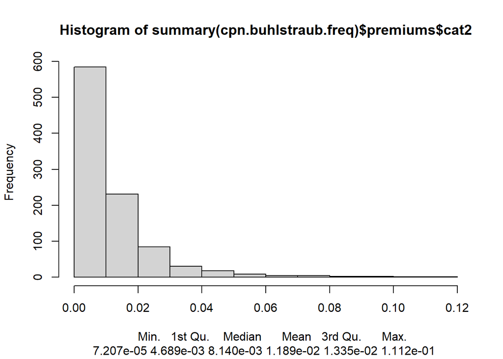

```r
hist(summary(cpn.buhlstraub.freq)$premiums$cat2, xlab=capture.output(summary(summary(cpn.buhlstraub.freq)$premiums$cat2)))
```

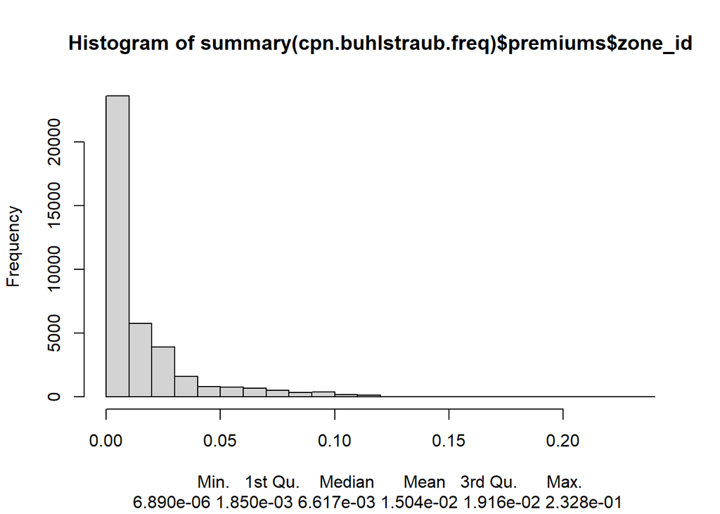

```r
hist(summary(cpn.buhlstraub.freq)$premiums$zone_id, xlab=capture.output(summary(summary(cpn.buhlstraub.freq)$premiums$zone_id)))
```

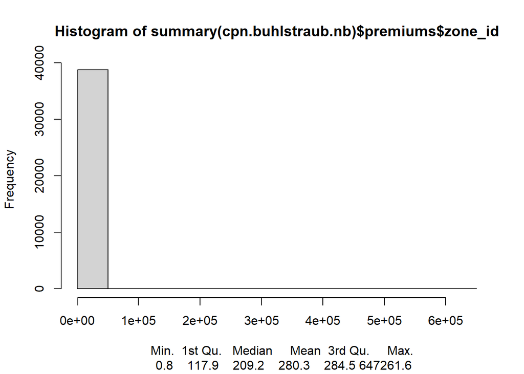

```r
hist(summary(cpn.buhlstraub.nb)$premiums$zone_id, xlab=capture.output(summary(summary(cpn.buhlstraub.nb)$premiums$zone_id)))
```

# 3 Basic buhlmann Straub model for both market and company

## 3.1 load dataset

We keep only years 2003 to 2008 because the company is not available outside that period.

```r
tapply(cpnmkt.unbal$Expo2003, cpnmkt.unbal$Entity, summary)
```

```
## $Company
##    Min. 1st Qu.  Median    Mean 3rd Qu.    Max.    NA's
##       2     300    1074    5657    3952  647110   25401
##
## $Market
##      Min.   1st Qu.    Median      Mean   3rd Qu.      Max.      NA's
##         2       354      1600     44677      8320 255776710    149731
```

```r
tapply(cpnmkt.unbal$Freq2003, cpnmkt.unbal$Entity, summary)
```

```
## $Company
##    Min. 1st Qu.  Median    Mean 3rd Qu.    Max.    NA's
##   0.000   0.000   0.000   0.015   0.000   0.500   25401
##
## $Market
##    Min. 1st Qu.  Median    Mean 3rd Qu.    Max.    NA's
##    0.00    0.00    0.00    0.01    0.00    0.50  149731
```

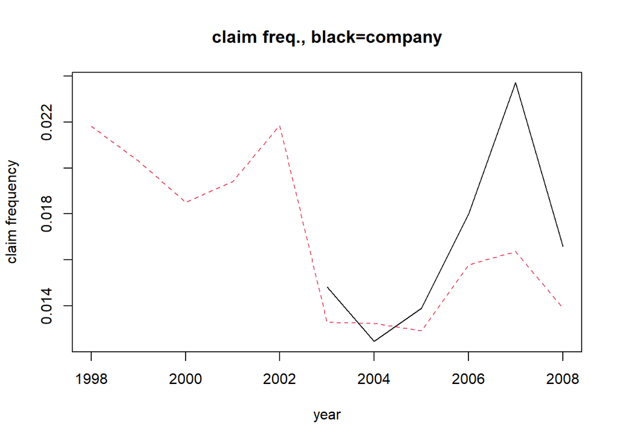

```r
colclaims <- grep("Claims", colnames(cpnmkt.unbal), value=TRUE)
colexpo <- grep("Expo", colnames(cpnmkt.unbal), value=TRUE)
colfreq <- grep("Freq", colnames(cpnmkt.unbal), value=TRUE)

years <- as.numeric(substr(colclaims, 7, 10))

matplot(years,
  t(sapply(colfreq, function(col)
  tapply(cpnmkt.unbal[, col], cpnmkt.unbal$Entity, mean, na.rm=TRUE)))
, type="l", ylab="claim frequency", xlab="year", main="claim freq., black=company")
```

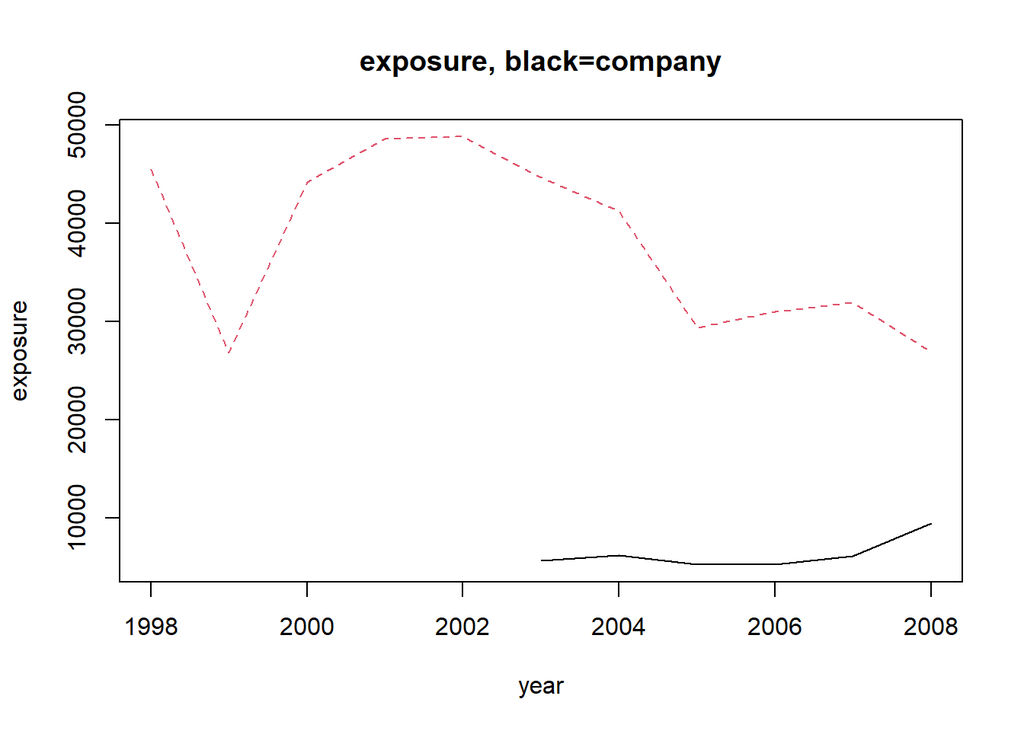

```r
matplot(years,
  t(sapply(colexpo, function(col)
  tapply(cpnmkt.unbal[, col], cpnmkt.unbal$Entity, mean, na.rm=TRUE)
)), type="l", ylab="exposure", xlab="year", main="exposure, black=company")
```

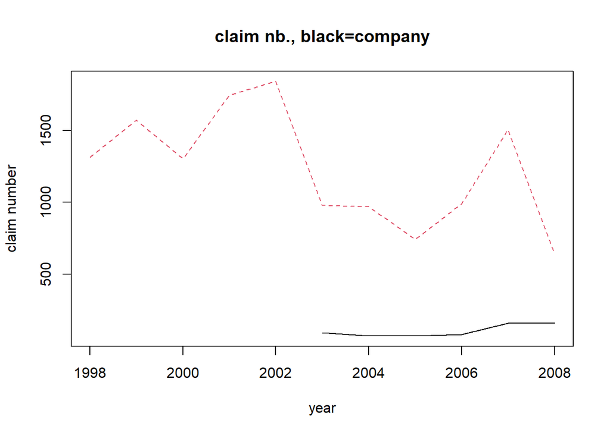

```r
matplot(years,
  t(sapply(colclaims, function(col)
  tapply(cpnmkt.unbal[, col], cpnmkt.unbal$Entity, mean, na.rm=TRUE)
)), type="l", ylab="claim number", xlab="year", main="claim nb., black=company")
```

## 3.2 Hierarchical Buhlmann Straub model

```r
head(cpnmkt.unbal)
```

```
##   Entity zone_id Expo1998 Expo1999 Expo2000 Expo2001 Expo2002 Expo2003 Expo2004
## 1 Market       5       50       50       50       40       NA       NA       NA
## 2 Market      16    19184    22322    18456    20940    10180    15026     8236
## 3 Market      20      412      380      120       80       NA       NA       NA
## 4 Market      23    11430    10690    16052    11610     6390    15320     8500
## 5 Market      26      700      900      800      900      300      800      800
## 6 Market      30      120      120       NA      164      120      352      360
##   Expo2005 Expo2006 Expo2007 Expo2008 Claims1998 Claims1999 Claims2000
## 1       NA       NA       NA       NA          0          0          0
## 2       NA    14446    11344    11026          0        213          0
## 3       NA       NA       80      100          0          0          0
## 4    15780    16366    14822    15766        220          0          0
## 5      800      400       NA       NA          0          0          0
## 6      360      368       NA       60         15         12         NA
##   Claims2001 Claims2002 Claims2003 Claims2004 Claims2005 Claims2006 Claims2007
```

[output cut: 41 more lines]

```r
cpnmkt.buhlstraub.nb <- cm(~ cat1+ cat1:cat2+ cat1:cat2:zone_id+ cat1:cat2:zone_id:Entity,
                           ratios=Claims2003:Claims2008,
                        weights=Expo2003:Expo2008, data=cpnmkt.unbal)
my.summary.cm(summary(cpnmkt.buhlstraub.nb))
```

```
## Call:
## cm(formula = ~cat1 + cat1:cat2 + cat1:cat2:zone_id + cat1:cat2:zone_id:Entity,
##     data = cpnmkt.unbal, ratios = Claims2003:Claims2008, weights = Expo2003:Expo2008)
##
## Structure Parameters Estimators
##
##   Collective premium: 34750.42
##
##   Between cat1 variance: 0
##   Within cat1/Between cat2 variance: 6064874748
##   Within cat2/Between zone_id variance: 65134793807
##   Within zone_id/Between Entity variance: 1778284786
##   Within Entity variance: 4.001896e+17
##
## Detailed premiums
##
##   Level: cat1
##     cat1 Indiv. mean  Weight       Cred. factor Cred. premium
##     0    1.646002e+02 2.771977e-02 0            34750.42
##     1    1.094000e+02 1.558307e-02 0            34750.42
##     2    1.094622e+03 2.703021e-01 0            34750.42
##  ...
##     cat1 Indiv. mean  Weight       Cred. factor Cred. premium
##     278  3.135981e+01 2.393848e-02 0            34750.42
##     279  3.004345e+03 3.758028e-01 0            34750.42
##     280  1.838384e+02 6.489489e-03 0            34750.42
##
##   Level: cat2
##     cat1 cat2 Indiv. mean  Weight       Cred. factor Cred. premium
##     0    6    1.684816e+02 1.881443e-01 1.721700e-02  34155.03
##     0    4    2.733965e+01 1.819233e-03 1.693650e-04  34744.54
##     0    5    7.427519e+00 2.920565e-02 2.712041e-03  34656.20
##  ...
##     cat1 cat2 Indiv. mean  Weight       Cred. factor Cred. premium
##     280  9    0.000000e+00 1.388636e-03 1.292829e-04  34745.93
##     280  11   2.165822e+02 4.452126e-02 4.128379e-03  34607.85
##     280  2    7.060167e+00 2.984336e-04 2.778718e-05  34749.46
##
##   Level: zone_id
##     cat1 cat2 zone_id Indiv. mean  Weight       Cred. factor Cred. premium
```

[output cut: 8 more lines]

```
##
##   Level: Entity
##     cat1 cat2 zone_id Entity Indiv. mean  Weight     Cred. factor Cred. premium
##       0   6      5    Market 0.000000e+00          0 0.000000e+00    34155.026
##       0   6     16    Market 3.597997e+02      60078 2.668917e-04    34249.151
##       0   6     20    Market 0.000000e+00        180 7.998485e-07    34543.815
##  ...
##     cat1 cat2 zone_id Entity  Indiv. mean  Weight     Cred. factor
##     280   2   2852    Market  0.000000e+00          6 2.666164e-08
##     280   4   2779    Company 0.000000e+00          4 1.777442e-08
##     280   6   2779    Company 0.000000e+00          4 1.777442e-08
##     Cred. premium
##        27221.258
##        27728.494
##        27728.494
```

```r
cpnmkt.buhlstraub.freq <- cm(~ cat1+ cat1:cat2+ cat1:cat2:zone_id+ cat1:cat2:zone_id:Entity,
                             ratios=Freq2003:Freq2008,
                          weights=Expo2003:Expo2008, data=cpnmkt.unbal)
my.summary.cm(summary(cpnmkt.buhlstraub.freq))
```

```
## Call:
## cm(formula = ~cat1 + cat1:cat2 + cat1:cat2:zone_id + cat1:cat2:zone_id:Entity,
##     data = cpnmkt.unbal, ratios = Freq2003:Freq2008, weights = Expo2003:Expo2008)
##
## Structure Parameters Estimators
##
##   Collective premium: 0.01377584
##
##   Between cat1 variance: 1.16604e-05
##   Within cat1/Between cat2 variance: 0.0001203863
##   Within cat2/Between zone_id variance: 0.0001447499
##   Within zone_id/Between Entity variance: 1.559636e-05
##   Within Entity variance: 58.73057
##
## Detailed premiums
##
##   Level: cat1
##     cat1 Indiv. mean Weight      Cred. factor Cred. premium
##     0    0.016294402 1.648609359 0.1376942218 0.014122632
##     1    0.017985596 1.311296244 0.1126963254 0.014250265
##     2    0.015971344 2.693739615 0.2069225694 0.014230140
##  ...
##     cat1 Indiv. mean Weight      Cred. factor Cred. premium
##     278  0.009057562 1.548898569 0.1304526414 0.013160329
##     279  0.013363061 2.230243682 0.1776434275 0.013702513
##     280  0.025280070 0.599894987 0.0549140169 0.014407584
##
##   Level: cat2
##     cat1 cat2 Indiv. mean  Weight       Cred. factor Cred. premium
##     0    6    8.993265e-03 2.194093e+00 6.459918e-01 0.010809103
##     0    4    1.337799e-02 2.693810e-02 2.191306e-02 0.014106315
##     0    5    4.359306e-03 4.180422e-01 2.579837e-01 0.011603853
##  ...
##     cat1 cat2 Indiv. mean  Weight       Cred. factor Cred. premium
##     280  9    0.000000e+00 2.057790e-02 1.682635e-02 0.014165157
##     280  11   2.257205e-02 6.360683e-01 3.459813e-01 0.017232336
##     280  2    5.195249e-02 4.503414e-03 3.731444e-03 0.014547681
##
##   Level: zone_id
##     cat1 cat2 zone_id Indiv. mean  Weight       Cred. factor Cred. premium
```

[output cut: 8 more lines]

```
##
##   Level: Entity
##     cat1 cat2 zone_id Entity Indiv. mean  Weight     Cred. factor Cred. premium
##       0   6      5    Market 0.000000e+00          0 0.000000e+00 1.080910e-02
##       0   6     16    Market 3.150904e-02      60078 1.570364e-02 1.722794e-02
##       0   6     20    Market 0.000000e+00        180 4.779811e-05 1.063680e-02
##  ...
##     cat1 cat2 zone_id Entity  Indiv. mean  Weight     Cred. factor
##     280   2   2852    Market  0.000000e+00          6 1.593344e-06
##     280   4   2779    Company 0.000000e+00          4 1.062230e-06
##     280   6   2779    Company 0.000000e+00          4 1.062230e-06
##     Cred. premium
##     1.679462e-02
##     1.795060e-02
##     1.795060e-02
```